# Post Goals:

1. F-Test comparing two population variances.
2. Comparing two population proportions.

# F-Test comparing two population variances.

**The basics**

- The F distribution is a derived distribution with two degrees of freedom $F_{df_1, df_2}$
- The F-test uses the F distribution to compare two population variances.
- Unlike the t-test that is robust as long as the sample size is large enough, the F test needs to be normally distributed.
- Assumptions:
  - Two random samples from respective populations
  - The sampels are independent of one another
  - The two populations are normally distributed with $N(\mu_1, \sigma_1)$ and $N(\mu_2, \sigma_2)$
- Hypothesis test:
  $$\begin{aligned} H_0\colon\sigma_1^2/\sigma_2^2=1\quad\text{against}\quad&H_a\colon\sigma_1^2/\sigma_2^2\ne1\\ \text{or}\quad&H_a\colon\sigma_1^2/\sigma_2^2>1\\ \text{or}\quad&H_a\colon\sigma_1^2/\sigma_2^2<1 \end{aligned}$$
- Hypothesis test values:
  - Parameter of interest. $$\colon\sigma_1^2/\sigma_2^2$$
  - Point estimate. $$\colons^2/s^2$$
  - Standard error under $H_0$: $$\widehat{\mathsf{SE}}=\sqrt{\frac{s_p^2}{n_1}+\frac{s_p^2}{n_2}}=s_p\sqrt{\frac1{n_1}+\frac1{n_2}}$$
  - Test statistic. $$f=\frac{s_1^2}{s_2^2}$$
  - Null distribution: F distribution
  - Degrees of freedom: $$df_{num}=n_1 -1$$ and $$df_{denom}=n_2 -1$$
- Confidence intervals:
  - Calculated as $100(1- \alpha)$
  - Two-sides: $$\left(\frac{s_1^2/s_2^2}{f_{n_1-1,n_2-1,\alpha/2}}, \frac{s_1^2/s_2^2}{f_{n_1-1,n_2-1,1-\alpha/2}}\right)$$
  - Upper one-sided: $$\left(0,\frac{s_1^2/s_2^2}{f_{n_1-1,n_2-1,1-\alpha}}\right)$$
  - Lower one-sided: $$\left(\frac{s_1^2/s_2^2}{f_{n_1-1,n_2-1,\alpha}},\infty\right)$$
- R code`var.test`

# Example 1: Determine if inspections performed by new and seasoned employees have the same variance

```r
insp <- read.csv('data/inspection.errors.csv')
attach(insp)
insp
```

A data.frame: 24 × 2

| group <chr> | errors <int> |
| --- | --- |
| Novice | 30 |
| Novice | 35 |
| Novice | 26 |
| Novice | 40 |
| Novice | 36 |
| Novice | 20 |
| Novice | 45 |
| Novice | 31 |
| Novice | 33 |
| Novice | 29 |
| Novice | 21 |
| Novice | 48 |
| Experienced | 31 |
| Experienced | 15 |
| Experienced | 25 |
| Experienced | 19 |
| Experienced | 28 |
| Experienced | 17 |
| Experienced | 19 |
| Experienced | 18 |
| Experienced | 24 |
| Experienced | 10 |
| Experienced | 20 |
| Experienced | 21 |

# Exploratory Data Analysis

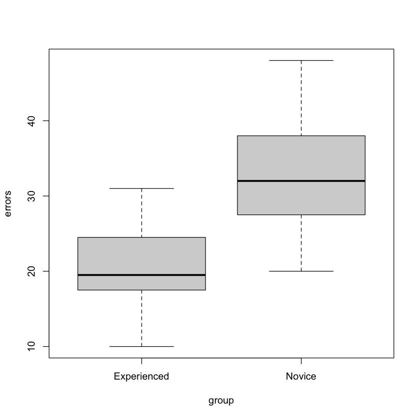

```r
# Visual data
boxplot(errors~group)
```

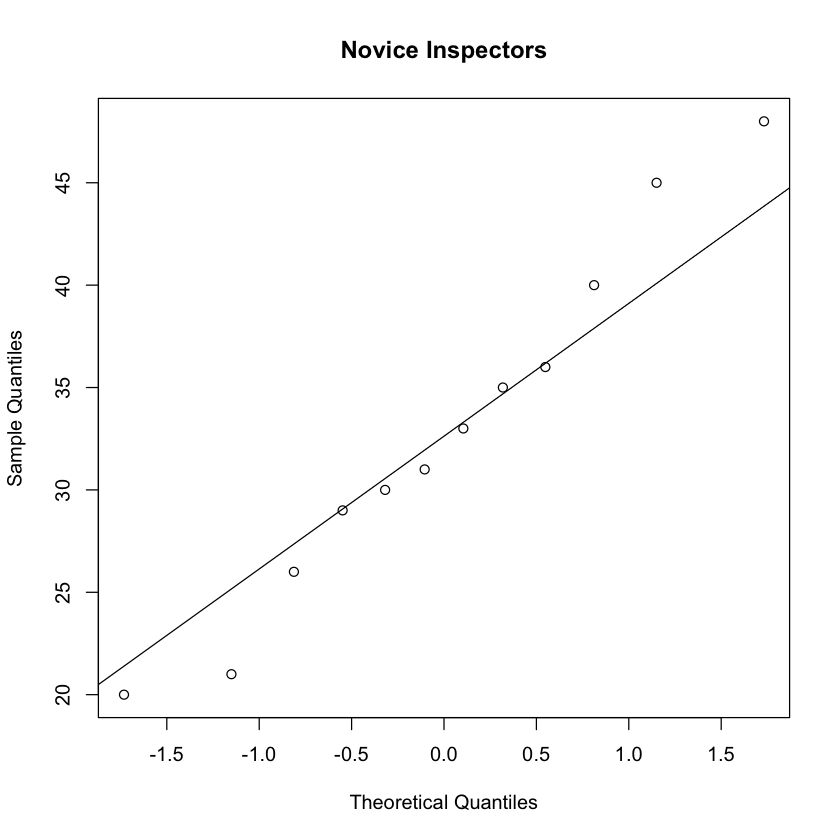

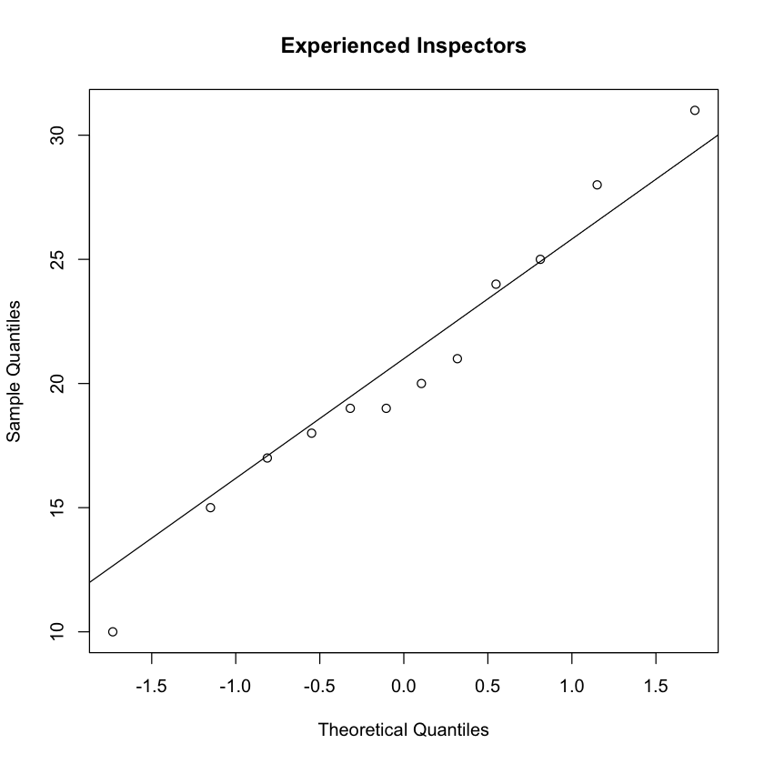

```r
# check normality
errors.nov <- errors[group=='Novice']
errors.exp <- errors[group=='Experienced']
qqnorm(errors.nov, main='Novice Inspectors'); qqline(errors.nov)
qqnorm(errors.exp, main='Experienced Inspectors'); qqline(errors.exp)
```

```r
aggregate(errors~group, FUN=summary)
```

A data.frame: 2 × 2

| group <chr> | errors <dbl[,6]> |
| --- | --- |
| Experienced | 10, 17.75, 19.5, 20.58333, 24.25, 31 |
| Novice | 20, 28.25, 32.0, 32.83333, 37.00, 48 |

```r
aggregate(errors~group, FUN=sd)
```

A data.frame: 2 × 2

| group <chr> | errors <dbl> |
| --- | --- |
| Experienced | 5.743903 |
| Novice | 8.642741 |

## Novice have higher errors than experienced staff, conduct F test using manual method and var.test at 90% confidece and alpha = 0.1

```r
s1 <- 5.7439
s2 <- 8.6427
df <- 12 - 1
f_test_statistic <- s1^2/s2^2; f_test_statistic
p.value <- pf(f_test_statistic, 11, 11, lower.tail=TRUE); p.value
```

0.441687251233849

0.0955488789869389

```r
var.test(errors~group, alt='l', conf.level=.9)
```

```
	F test to compare two variances

data:  errors by group
F = 0.44168, num df = 11, denom df = 11, p-value = 0.09555
alternative hypothesis: true ratio of variances is less than 1
90 percent confidence interval:
 0.0000000 0.9835986
sample estimates:
ratio of variances
         0.4416836
```

# Comparing two population proportions.

**The Basics**

- Procedure for comparing two population proportion is similar to comparing two population means.
- The following procedure will compare two population proportions $p_1 - p_2$ by comparing the differenced between the two proportions $\hat{p_1} - \hat{p_2}$.
- Assumptions:
  - Random smamples from both populations, and each sampliing unit to be success or failure.
  - The two samples are independent of one another.
  - The two sample sizes are large enough to invoke the central limit theorem.
  - Rule of thumb, $np \geq 5$ and $n(1-p) \geq 5$.
- Hypothesis test:
  $$\begin{aligned} H_0\colon p_1=p_2\quad\text{against}\quad&H_a\colon p_1\ne p_2\\ \text{or}\quad&H_a\colon p_1p_2 \end{aligned}$$
- Hypothesis test values:
  - Parameter of interest. $p_1 = p_2$
  - Point estimate. $\hat{p_1} - \hat{p_2}$
  - Standard error under $H_0$: $$\sqrt{\hat p(1-\hat p)(\frac{1}{n_1}+\frac{1}{n_2})}$$
  - Test statistic. $$z=\frac{\hat p_1-\hat p_2}{\sqrt{\hat p(1-\hat p)(\frac{1}{n_1}+\frac{1}{n_2})}}$$
  - Null distribution: $\mathsf{N}(0,1)$ Distribution
  - Degrees of freedom: None
  - The pooled sample proportion: $$\hat p_1=\frac{x_1}{n_1},\quad \hat p_2=\frac{x_2}{n_2},\quad\hat p=\frac{x_1+x_2}{n_1+n_2}$$
- Confidence intervals:
  - Calculated as $100(1- \alpha)$
  - Two-sides: $$\left(\hat p_1-\hat p_2\pm z_{\alpha/2}\sqrt{\hat p_1(1-\hat p_1)/n_1+\hat p_2(1-\hat p_2)/n_2}\right)$$
  - Upper one-sided: $$\left(-1,\hat p_1-\hat p_2+ z_{\alpha}\sqrt{\hat p_1(1-\hat p_1)/n_1+\hat p_2(1-\hat p_2)/n_2}\right)$$
  - Lower one-sided: $$\left(\hat p_1-\hat p_2- z_{\alpha}\sqrt{\hat p_1(1-\hat p_1)/n_1+\hat p_2(1-\hat p_2)/n_2},1\right)$$
- R method: `prop.test(x, n, alt=TYPE, conf.level=CL, correct=FALSE)`

# Example 2:

- Compare bike tire strength during 1 week of usage in the same area by the same bike messenger.
- Brand A, 34 tires pop, 66 do not pop, total 100
- Brand B, 25 tires pop, 75 do not pop, total 100
- Test Brand A proportio of tires pop is gretear than the proportion for Brand B
- Alpha = 0.05

```r
# z-test critical value
qnorm(0.05, lower.tail=FALSE)
```

1.64485362695147

```r
# proportions
p_a <- 34/100; p_a
p_b <- 25/100; p_b
sample_pooled <- (34+25)/(200); sample_pooled
se <- sqrt(sample_pooled*(1-sample_pooled)*(1/100 + 1/100));se
z_stat <- (p_a-p_b)/se; z_stat
p.value <- pnorm(z_stat, lower.tail=FALSE);p.value
```

0.34

0.25

0.295

0.0644941857844566

1.39547462930667

0.0814363801211155

```r
prop.test(c(34,25), c(100,100), alt='g', conf.level=0.95, correct=FALSE)
```

```
	2-sample test for equality of proportions without continuity
	correction

data:  c(34, 25) out of c(100, 100)
X-squared = 1.9473, df = 1, p-value = 0.08144
alternative hypothesis: greater
95 percent confidence interval:
 -0.01556578  1.00000000
sample estimates:
prop 1 prop 2
  0.34   0.25
```